# Blood Feeding and Human Biting Rate Calculators

David Smith

2022-06-22

Library | Primer / Blood Feeding

## .

These blood feeding calculators are designed to support a model of blood feeding and the HBR that is currently described more fully in an [Overleaf manuscript](https://www.overleaf.com/read/wwbqzwzzcbny).

## Framework

### .

In the diagram below, the rhombus shapes are required inputs. More precisely, we need:

- A sub-division of the day into $\tau$ equal periods
- A sub-division of space into $p$ patches
- A sub-division of a human population into $n$ strata.
  - For each stratum, we need a vector of indices for the patch where humans in the stratum live, $i \in 1,2, \ldots, p$.
  - We use this vector to generate a membership matrix $\cal J$ such that ${\cal J} \cdot H = P$, where $P$ is the census population.
- The number of humans in each stratum is denoted by a vector $H$.
- For $t \in 1, 2, \ldots, \tau$, we need to specify $\tau$ $p \times n$ matrices, $\Theta_t$:
  - Each one of the matrices describes time spent by the human population stratat for one time of the day.
  - Each row of each matrix $\Theta_t$ describes the fraction of time spent in each patch by one of the strata.
- We supply a single vector $O$ of length $p$ describing other available hosts, and we supply a scaling parameter $\xi$. In some cases, it may be useful to let $O$ vary by time of day, in which case we must pass a matrix of $\tau$ vectors.
- A vector of length $\tau$ of circadian weights, $\xi_t$, describes *relative blood feeding activity rates* by time of day. If this is passed from tabular data, it is normalized by the mean.
- A matrix of dimension $\tau \times n$ of search weights. Each row of the matrix is a vector $w_t$ of length $n$ describing the biting weights for each one of the strata at this time of the day.
- A function $P_\tau(\xi)$ that scales $\xi$ so that it can be interpreted as the fraction of mosquitoes that attempt to blood feed in each time period.
- A function $F_\tau(B)$ that describes blood feeding success during a single time period for a searching mosquito.

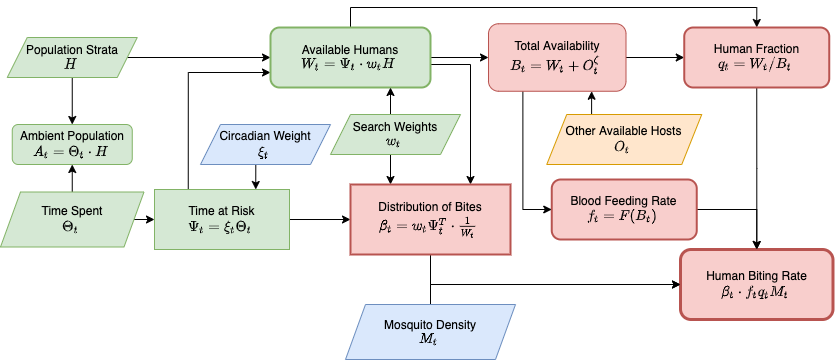

## Models

### .

We have formulated two specific models:

- **Focal Patch** is a dramatically simplified version of the model that takes tabular data as input:
- A fully-defined model with multiple spatial areas, with indoor and outdoor patches for each area.

### Focal Patch

#### .

- By default, we assume the day is sub-divided into 24 1-hours periods.
- Patch definitions: We assume there are three patches: **away**, **outdoors**, and **indoors**
- Human Population Strata: We assume there is a single population stratum.
- Time Spent: for each time period, we supply a vector describing
  - fraction of time spent away from home
  - fraction of time spent outdoors at home
  - fraction of time spent indoors at home
  - fraction of time spent indoors and in bed
- A vector describing circadian biting weights
- The total number of humans at *home* and *away*
- The availability of other hosts at *home* and *away*
- The number of blood feeding mosquitoes at *home* and *away*

#### Outputs

- For a parameter $\phi$ describing the fraction of bedtime that a net is used.
  - the reduction in the *dHBR* for a focal person using the net
  - the reduction in the fraction of mosquitoes that blood fed
  - the reduction in the fraction of mosquitoes that blood fed on a human
  - the proportion of *dHBR* that occurred **away** *vs.* **at home**

## Algorithms

### Time Spent

- At home, outdoors
- Indoors, not in bed
- Indoors, in bed, not under a net
- Indoors, in bed, under a net

To get started, we need to have some basic pseudo-data to play with, so we write some functions to generate sensible patterns. These are meant to help illustrate what the calculator does. The calculator itself works on tabular data.

```r
timeSpentByHour = function(t,params){
  UseMethod("timeSpentByHour", params)
}
```

```r
timeSpentByHour.sin = function(t, params){with(params,{
  ts = amp*(1+eps+sin(2*pi*(t+offset)/24))
  ts = pmin(pmax(ts,0),1)
  return(ts)
})}

timeSpentByHour_sin = function(offset=3, pwr=1, eps=0, mn=0.05, amp=1){
 params = list()
 class(params) <- "sin"
 params$offset = offset
 params$pwr = pwr
 params$eps = eps
 params$mn = mn
 params$amp = amp
 return(params)
}
```

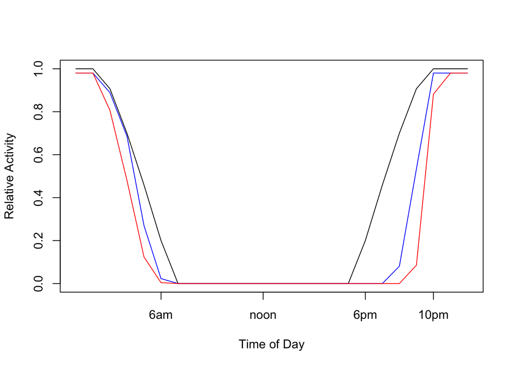

```r
atHome = timeSpentByHour(1:24, timeSpentByHour_sin(6, 3, -0.8))
inside = timeSpentByHour(1:24, timeSpentByHour_sin(5, 3, -1.2, 0, 2))*atHome*0.98
inBed  = timeSpentByHour(1:24, timeSpentByHour_sin(4, 3, -1.2, 0, 3))*atHome*inside
plot(1:24, atHome, type = "l", ylim = range(0, 1), xlab = "Time of Day", ylab = "Relative Activity", xaxt="n")
lines(1:24, inside, col = "blue")
lines(1:24, inBed, col = "red")
axis(1, c(6, 12, 18, 22), c("6am", "noon", "6pm", "10pm"))
```

```r
noon2noon = function(ftime, clr = "black", add=F){
  ix = c(13:24, 1:12)
  if(add==F) {
    plot(1:24, ftime[ix], type = "l", xaxt = "n", xlab = "Time of Day", ylab = "Relative Activity", col = clr)
    axis(1, c(6, 10, 18, 24), c("6pm", "10 pm", "6 am", "noon"))
  }
  if(add==T) lines(1:24, ftime[ix], col = clr)
}
```

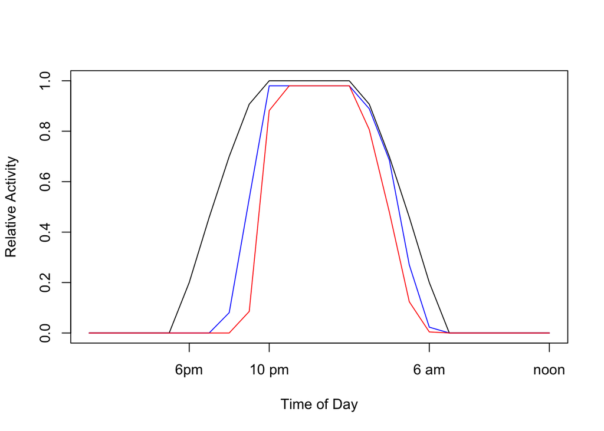

```r
noon2noon(atHome)
noon2noon(inside, "blue", T)
noon2noon(inBed, "red", T)
```

### Circadia

We let $\xi(t)$ denote relative mosquito activity rates.

```r
mozyBFActivityByHour = function(t,params){
  UseMethod("mozyBFActivityByHour", params)
}
```

```r
mozyBFActivityByHour.sin = function(t, params){with(params,{
  crude = pmax(1+eps+sin(2*pi*(t+offset)/24),0) + mn
  return(crude/mean(crude))
})}

paramsBFActivityByHour_sin = function(offset=3, pwr=1, eps=0, mn=0.05){
 params = list()
 class(params) <- "sin"
 params$offset = offset
 params$pwr = pwr
 params$eps = eps
 params$mn = mn
 return(params)
}
```

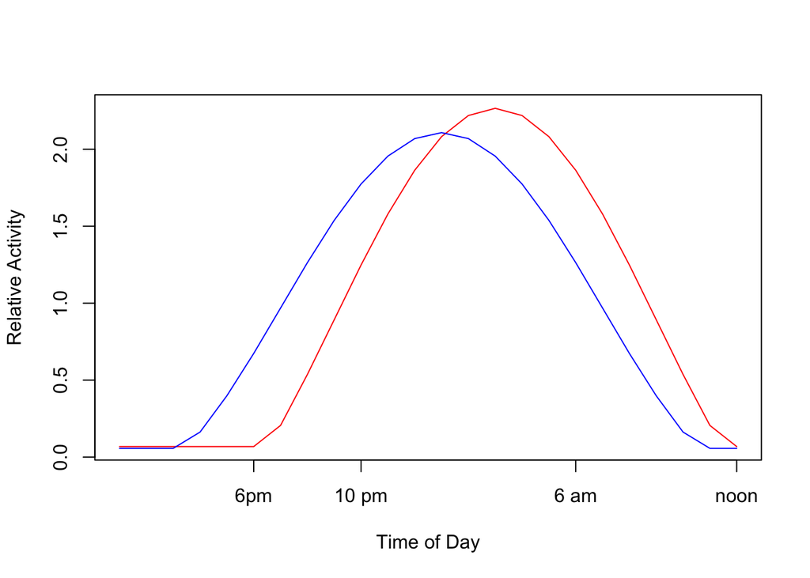

```r
circ1 = mozyBFActivityByHour(1:24, paramsBFActivityByHour_sin(3,3,-0.4))
circ2 = mozyBFActivityByHour(1:24, paramsBFActivityByHour_sin(5,3,-0.2))
noon2noon(circ1, "red")
noon2noon(circ2, "blue", T)
```